# Physical Threshold Selection - Don River

Dylan

2026-03-29

## Overview

This notebook documents how the physical flood threshold u_physical was selected for the Don River at Todmorden (02HC024). u_physical is the flow level in m³/s at which water leaves the Don River channel and causes real world damage. It is used to define flood events for the frequency model and as the lower bound for the Bayesian MRL grid search in the next notebook.

The process was not straightforward. The initial approach attempted to use the official TRCA flood warning threshold but was abandoned due to an irreconcilable reference system mismatch between TRCA and Environment Canada data. Three independent empirical approaches were then used to converge on a defensible value. Each approach and its limitations are documented transparently below.

## 1. Load Data

```r
library(tidyverse)
library(here)

flow_data    <- read_csv(here::here("data", "clean", "02HC024_clean.csv"))
rating_curve <- read_csv(here::here("data", "clean", "02HC024_rating_curve_clean.csv"))
```

## 2. Understanding The Water Level Data And The TRCA Problem

The Environment Canada water level data uses a local gauge datum, not elevation above sea level. For 02HC024 Todmorden the normal water level reads approximately **12.1m** in the EC data. TRCA’s real-time gauging system reports the same station using metres above sea level (MASL):

```r
trca_levels <- tibble(
  level       = c("Normal", "Low Alarm", "High Alarm", "High-High Alarm"),
  water_level = c(77.59, 78.70, 79.00, 79.30),
  reference   = "TRCA Real-Time Gauging (MASL)"
)
trca_levels
```

```
## # A tibble: 4 × 3
##   level           water_level reference
##   <chr>                 <dbl> <chr>
## 1 Normal                 77.6 TRCA Real-Time Gauging (MASL)
## 2 Low Alarm              78.7 TRCA Real-Time Gauging (MASL)
## 3 High Alarm             79   TRCA Real-Time Gauging (MASL)
## 4 High-High Alarm        79.3 TRCA Real-Time Gauging (MASL)
```

The High Alarm level of **79.0m** MASL was the natural starting point as TRCA defines this as the level at which active flooding occurs. The implied datum offset of **65.4m** was estimated by taking the difference between the two normal level readings: TRCA reports 77.59m MASL while Environment Canada records 12.21m for the same normal conditions, giving 77.59 minus 12.21 equals 65.38m. **Converting the High Alarm level to local datum then gives approximately 13.6m (79.0 minus 65.4), suggesting 14.0m** as a reasonable working estimate for the flood threshold in EC units. However this offset was estimated not verified against an official benchmark elevation document, making 14.0m an approximation rather than an authoritative value.

The water level data covers 2002 onward and has a maximum observed value of 13.54m, which never reached the estimated 14.0m flood threshold. This means the threshold cannot be validated against observed discharge data.

All three approaches below therefore work directly from the discharge record. A future improvement would be to contact TRCA or Environment Canada directly to obtain the official benchmark elevation for 02HC024, which would allow direct conversion and independent validation of u_physical against the official warning threshold.

## 3. Rating Curve — Water Level vs Discharge

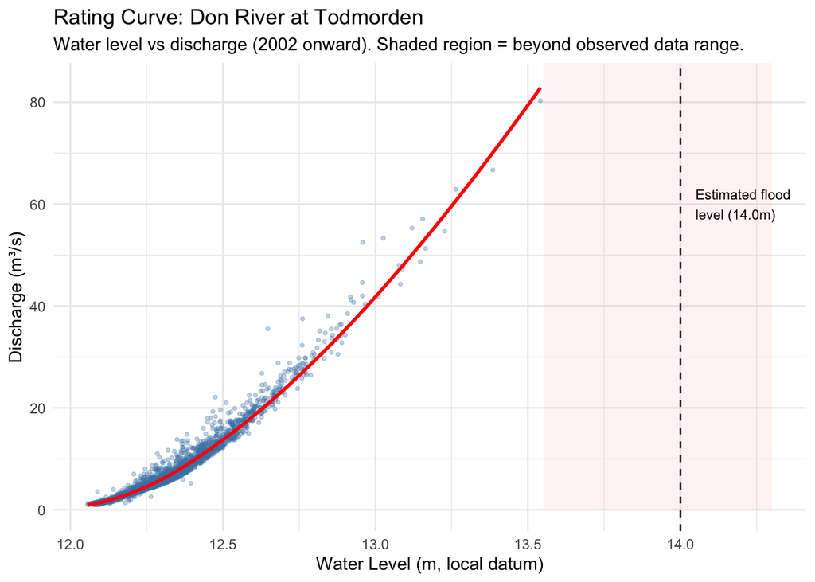

```r
ggplot(rating_curve, aes(x = water_level_m, y = discharge_m3s)) +
  geom_point(alpha = 0.3, size = 0.8, colour = "steelblue") +
  geom_smooth(method = "loess", colour = "red",
              se = TRUE, alpha = 0.1) +
  geom_vline(xintercept = 14.0, colour = "black",
             linetype = "dashed") +
  annotate("text", x = 14.05, y = 60,
           label = "Estimated flood\nlevel (14.0m)",
           hjust = 0, size = 3) +
  annotate("rect", xmin = 13.55, xmax = 14.3,
           ymin = 0, ymax = Inf,
           alpha = 0.05, fill = "red") +
  theme_minimal() +
  labs(
    title    = "Rating Curve: Don River at Todmorden",
    subtitle = "Water level vs discharge (2002 onward). Shaded region = beyond observed data range.",
    x        = "Water Level (m, local datum)",
    y        = "Discharge (m³/s)"
  )
```

The rating curve shows a clear positive relationship between water level and discharge. The estimated flood threshold of 14.0m lies in the shaded region beyond the observed data range, making any extrapolation unreliable.

## 4. Highest Observed Water Level Events

```r
rating_curve %>%
  arrange(desc(water_level_m)) %>%
  select(YEAR, month_name, DD, water_level_m, discharge_m3s) %>%
  head(20)
```

```
## # A tibble: 20 × 5
##     YEAR month_name DD    water_level_m discharge_m3s
##    <dbl> <chr>      <chr>         <dbl>         <dbl>
##  1  2009 Feb        12             13.5          80.3
##  2  2020 Jan        12             13.4          66.7
##  3  2020 Jan        11             13.3          62.9
##  4  2005 Aug        20             13.2          54.7
##  5  2011 Mar        11             13.2          51.3
##  6  2013 May        29             13.2          57.1
##  7  2018 Apr        16             13.1          48.7
##  8  2005 Aug        19             13.1          55.3
##  9  2017 Jun        23             13.1          47.8
## 10  2022 Feb        17             13.1          47.1
## 11  2017 May        05             13.1          44.3
## 12  2023 Jun        12             13.1          48
## 13  2013 Jul        08             13.0          53.3
## 14  2006 Dec        01             13.0          41.8
## 15  2011 Nov        29             13.0          40.4
## 16  2012 Sep        04             13.0          52.5
## 17  2008 Jul        23             13.0          42
## 18  2009 Apr        03             13.0          44.6
## 19  2010 Aug        22             12.9          40.7
## 20  2012 Sep        08             12.9          41.2
```

The highest observed water levels between 13.0 and 13.5m correspond to discharge values of approximately 40 to 80 m³/s. The 2013 July flood appears at 53.3 m³/s, consistent with what HYDAT records for that date.

## 5. Approach 1: Extrapolation From Rating Curve

```r
rating_model <- lm(log(discharge_m3s) ~ water_level_m,
                   data = rating_curve)

predicted      <- predict(rating_model,
                          newdata = data.frame(water_level_m = 14.0))

(u_extrapolated <- round(exp(predicted), 1))
```

```
##       1
## 27378.9
```

The log-linear extrapolation to 14.0m produces an estimated discharge of 2.73789^{4} m³/s, a physically impossible result. The Amazon River flows at around 200,000 m³/s and the Don River at its worst recorded event was approximately 400 to 500 m³/s. This confirms that extrapolating 0.5m beyond the observed water level range is unreliable. Hence, approach 1 is a discarded.

## 6. Approach 2: Known Historical Flood Events

Toronto’s Don River has a well documented flood history. The following events were identified through Environment Canada discharge records, IBC catastrophe loss reports, and the Canadian Disaster Database:

```r
flood_events <- tibble(
  date   = as.Date(c(
    "1954-10-15",
    "1986-04-14",
    "2013-07-08",
    "2017-05-04",
    "2019-05-24"
  )),
  event  = c(
    "Hurricane Hazel",
    "Spring freshet flooding",
    "July thunderstorm — Toronto flash flood",
    "Spring freshet flooding",
    "Spring freshet flooding"
  ),
  type   = c(
    "Fluvial",
    "Fluvial",
    "Pluvial/Fluvial",
    "Fluvial",
    "Fluvial"
  ),
  source = c(
    "Canadian Disaster Database",
    "Environment Canada discharge record",
    "IBC — $940M insured loss (Ontario)",
    "Environment Canada discharge record",
    "Environment Canada discharge record"
  )
)

flood_events
```

```
## # A tibble: 5 × 4
##   date       event                                   type            source
##   <date>     <chr>                                   <chr>           <chr>
## 1 1954-10-15 Hurricane Hazel                         Fluvial         Canadian D…
## 2 1986-04-14 Spring freshet flooding                 Fluvial         Environmen…
## 3 2013-07-08 July thunderstorm — Toronto flash flood Pluvial/Fluvial IBC — $940…
## 4 2017-05-04 Spring freshet flooding                 Fluvial         Environmen…
## 5 2019-05-24 Spring freshet flooding                 Fluvial         Environmen…
```

Cross referencing these dates against the HYDAT flow data:

```r
confirmed_flood_flows <- flow_data %>%
  filter(date %in% flood_events$date) %>%
  filter(!is.na(flow)) %>%
  left_join(flood_events, by = "date") %>%
  select(date, event, type, flow)

confirmed_flood_flows
```

```
## # A tibble: 4 × 4
##   date       event                                   type             flow
##   <date>     <chr>                                   <chr>           <dbl>
## 1 1986-04-14 Spring freshet flooding                 Fluvial          2.02
## 2 2013-07-08 July thunderstorm — Toronto flash flood Pluvial/Fluvial 53.3
## 3 2017-05-04 Spring freshet flooding                 Fluvial         11.6
## 4 2019-05-24 Spring freshet flooding                 Fluvial          2.65
```

The 2013 event records a daily mean of 53.3 m³/s, the highest value for any known flood date in the HYDAT record. The 2017 and 2019 values appear low. This is a consequence of using daily mean discharge.(flood that peaked for 6 to 12 hours gets averaged across the full 24 hour day, significantly understating the true peak flow)

Hurricane Hazel (1954) is absent from the HYDAT comparison because records for 02HC024 only begin in 1961. Hazel is historically documented as the most catastrophic flood event on the Don River with peak flows on the Humber River reaching approximately 1,700 m³/s. Its inclusion here acknowledges the existence of extreme tail events beyond the observed record, directly relevant to the GPD shape parameter discussion in the severity model notebook.

The minimum daily mean across all confirmed flood dates where HYDAT data exists is 2 m³/s and the maximum is 53.3 m³/s. These are daily means, true instantaneous peaks were substantially higher. u_physical should be below this minimum to ensure all genuine flood events are captured while remaining above normal flow conditions.

The 2013 event is classified as primarily **pluvial**: the discharge recorded at the gauge reflects a combination of surface runoff and riverine flow that cannot be separated at daily resolution. This event is included for completeness and as an upper bound reference but is not used as a primary anchor for u_physical given the fluvial focus of this model. The threshold is derived primarily from the percentile analysis and sensitivity table in Sections 7 and 8.

## 7. Approach 3: Flow Percentiles

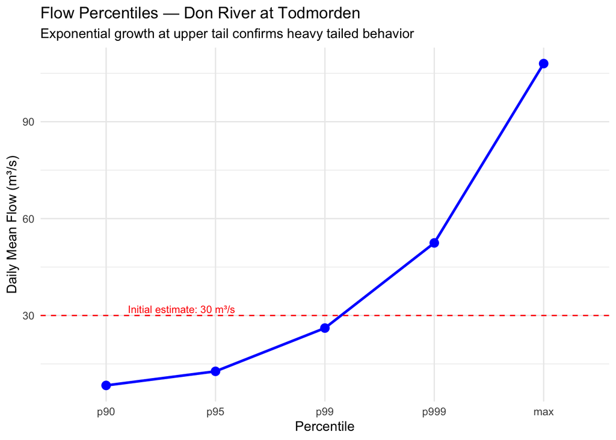

```r
p_flow_tbl <- flow_data %>%
  summarise(
    p90  = quantile(flow, 0.90,  na.rm = TRUE),
    p95  = quantile(flow, 0.95,  na.rm = TRUE),
    p99  = quantile(flow, 0.99,  na.rm = TRUE),
    p999 = quantile(flow, 0.999, na.rm = TRUE),
    max  = max(flow, na.rm = TRUE)
  ) %>%
  pivot_longer(
    cols      = everything(),
    names_to  = "percentile",
    values_to = "flow_m3s"
  ) %>%
  mutate(percentile = factor(percentile,
                             levels = c("p90", "p95", "p99",
                                        "p999", "max")))

ggplot(p_flow_tbl, aes(x = percentile, y = flow_m3s, group = 1)) +
  geom_line(colour = "blue", linewidth = 1) +
  geom_point(colour = "blue", size = 3) +
  geom_hline(yintercept = 30, colour = "red",
             linetype = "dashed") +
  annotate("text", x = 1.2, y = 32,
         label = "Initial estimate: 30 m³/s",
         colour = "red", size = 3, hjust = 0) +
  theme_minimal() +
  labs(
    title    = "Flow Percentiles — Don River at Todmorden",
    subtitle = "Exponential growth at upper tail confirms heavy tailed behavior",
    x        = "Percentile",
    y        = "Daily Mean Flow (m³/s)"
  )
```

```r
p_flow_tbl
```

```
## # A tibble: 5 × 2
##   percentile flow_m3s
##   <fct>         <dbl>
## 1 p90            8.34
## 2 p95           12.7
## 3 p99           26.1
## 4 p999          52.5
## 5 max          108
```

The jump from p99 to p99.9 is nearly double the jump from p95 to p99, and the jump from p99.9 to the maximum is larger still. This accelerating growth at the upper tail is the visual signature of heavy tailed behavior and directly supports GPD as the appropriate severity model.

## 8. Threshold Decision

### Sensitivity Analysis

Event counts were checked across a range of candidate thresholds before committing to 30 m³/s:

```r
sensitivity <- tibble(threshold = c(20, 25, 30, 35, 40)) %>%
  mutate(
    days_above   = map_int(threshold, ~sum(flow_data$flow >= .x,
                                           na.rm = TRUE)),
    pct_above    = round(days_above / nrow(flow_data) * 100, 2),
    rough_events = map_int(threshold, ~{
      flow_data %>%
        mutate(
          above     = flow >= .x,
          new_event = above & !lag(above, default = FALSE)
        ) %>%
        pull(new_event) %>%
        sum(na.rm = TRUE)
    })
  )

sensitivity
```

```
## # A tibble: 5 × 4
##   threshold days_above pct_above rough_events
##       <dbl>      <int>     <dbl>        <int>
## 1        20        437      1.95          348
## 2        25        249      1.11          208
## 3        30        150      0.67          130
## 4        35         91      0.41           84
## 5        40         59      0.26           54
```

A threshold of 30 m³/s sits in the sweet spot - **original thought**…

high enough to exclude normal elevated flow, low enough to retain sufficient events for GPD fitting, and consistent with the onset of flood-producing conditions observed in the rating curve and historical event record.

### First Decision

```r
U_PHYSICAL <- 30
```

The known limitation is that u_physical is defined in terms of daily mean discharge. True instantaneous flood peaks are higher. This conservative threshold partially compensates by capturing the onset of flood conditions rather than peak conditions.

Note that the event count here is a rough upper bound based on threshold crossings, not proper declustering. The full declustering algorithm using a 3 day minimum separation is implemented in notebook 03_event_extraction.Rmd.

### IMPORTANT CHANGE On u_physical After Declustering Analysis

After implementing the declustering function the following event characteristics were observed at u_physical = 30 m³/s:

```r
invisible(source(here::here("R_functions", "declustering.R"), echo = FALSE))
```

```
## ==========================================
## Declustering Complete
## ==========================================
## Threshold:          40.0 m3/s
## Min separation:     3 days
## Independent events: 54
## Years of record:    34
## Mean events/year:   0.87
## ==========================================
## Rows: 54
## Columns: 10
## $ event_id      <dbl> 1, 2, 3, 4, 5, 6, 7, 8, 9, 10, 11, 12, 13, 14, 15, 16, 1…
## $ start_date    <date> 1965-02-10, 1968-02-02, 1968-03-16, 1972-04-13, 1974-01…
## $ end_date      <date> 1965-02-10, 1968-02-02, 1968-03-16, 1972-04-13, 1974-01…
## $ year          <dbl> 1965, 1968, 1968, 1972, 1974, 1974, 1974, 1975, 1975, 19…
## $ month         <dbl> 2, 2, 3, 4, 1, 3, 5, 2, 4, 3, 12, 3, 7, 2, 3, 2, 3, 2, 1…
## $ season        <chr> "Winter", "Winter", "Spring", "Spring", "Winter", "Sprin…
## $ Q_peak        <dbl> 70.2, 61.7, 41.3, 43.3, 53.8, 54.7, 46.7, 58.9, 47.0, 45…
## $ duration      <int> 1, 1, 1, 1, 1, 1, 1, 1, 1, 1, 1, 1, 1, 1, 1, 2, 1, 2, 1,…
## $ volume_excess <dbl> 30.199997, 21.700001, 1.299999, 3.299999, 13.799999, 14.…
## $ excess_peak   <dbl> 30.199997, 21.700001, 1.299999, 3.299999, 13.799999, 14.…
```

```r
flood_events_30 <- decluster_events(
  flow_data            = flow_data,
  threshold            = 30,
  min_days_independent = 3
)
```

```
## ==========================================
## Declustering Complete
## ==========================================
## Threshold:          30.0 m3/s
## Min separation:     3 days
## Independent events: 129
## Years of record:    52
## Mean events/year:   2.08
## ==========================================
```

```r
flood_events_30 %>%
  summarise(
    n_events        = n(),
    mean_duration   = mean(duration),
    median_duration = median(duration),
    max_duration    = max(duration)
  )
```

```
## # A tibble: 1 × 4
##   n_events mean_duration median_duration max_duration
##      <int>         <dbl>           <int>        <int>
## 1      129          1.16               1            3
```

```r
flood_events_30 %>%
  arrange(start_date) %>%
  mutate(days_since_last = as.numeric(start_date - lag(end_date))) %>%
  summarise(
    mean_gap    = mean(days_since_last, na.rm = TRUE),
    median_gap  = median(days_since_last, na.rm = TRUE),
    min_gap     = min(days_since_last, na.rm = TRUE),
    pct_under_3 = mean(days_since_last < 3, na.rm = TRUE) * 100
  )
```

```
## # A tibble: 1 × 4
##   mean_gap median_gap min_gap pct_under_3
##      <dbl>      <dbl>   <dbl>       <dbl>
## 1     173.       94.5       4           0
```

The median event duration of 1 day confirms that the Don River responds and recovers rapidly at 30 m³/s, consistent with a small urban catchment with fast drainage. The minimum inter-event gap of 4 days and zero events separated by fewer than 3 days confirms all 129 events are independent. The 3 day separation criterion was therefore conservative for this dataset as natural event separation was already occurring.

However the 1 day median duration brings a physical concern. A single day spike barely above 30 m³/s is unlikely to represent a damaging flood event. The rating curve analysis in Section 4 showed all documented flood events correspond to daily means of 40 to 80 m³/s. Events between 30 and 40 m³/s likely represent elevated flow conditions rather than active flooding.

Comparing event characteristics across candidate thresholds:

```r
threshold_comparison <- tibble(threshold = c(30, 35, 40, 45, 50)) %>%
  mutate(
    n_events = map_int(threshold, \(u) {
      decluster_events(flow_data, u, 3) %>% nrow()
    }),
    median_duration = map_int(threshold, \(u) {
      events <- decluster_events(flow_data, u, 3)
      as.integer(median(events$duration))
    }),
    mean_Q_peak = map_dbl(threshold, \(u) {
      events <- decluster_events(flow_data, u, 3)
      round(mean(events$Q_peak), 1)
    })
  )
```

```
## ==========================================
## Declustering Complete
## ==========================================
## Threshold:          30.0 m3/s
## Min separation:     3 days
## Independent events: 129
## Years of record:    52
## Mean events/year:   2.08
## ==========================================
## ==========================================
## Declustering Complete
## ==========================================
## Threshold:          35.0 m3/s
## Min separation:     3 days
## Independent events: 83
## Years of record:    41
## Mean events/year:   1.34
## ==========================================
## ==========================================
## Declustering Complete
## ==========================================
## Threshold:          40.0 m3/s
## Min separation:     3 days
## Independent events: 54
## Years of record:    34
## Mean events/year:   0.87
## ==========================================
## ==========================================
## Declustering Complete
## ==========================================
## Threshold:          45.0 m3/s
## Min separation:     3 days
## Independent events: 35
## Years of record:    25
## Mean events/year:   0.56
## ==========================================
## ==========================================
## Declustering Complete
## ==========================================
## Threshold:          50.0 m3/s
```

[output cut: 80 more lines]

```
## Threshold:          45.0 m3/s
## Min separation:     3 days
## Independent events: 35
## Years of record:    25
## Mean events/year:   0.56
## ==========================================
## ==========================================
## Declustering Complete
## ==========================================
## Threshold:          50.0 m3/s
## Min separation:     3 days
## Independent events: 25
## Years of record:    19
## Mean events/year:   0.40
## ==========================================
```

```r
threshold_comparison
```

```
## # A tibble: 5 × 4
##   threshold n_events median_duration mean_Q_peak
##       <dbl>    <int>           <int>       <dbl>
## 1        30      129               1        42.2
## 2        35       83               1        47.7
## 3        40       54               1        53.4
## 4        45       35               1        59.4
## 5        50       25               1        64.2
```

Raising u_physical to 40 m³/s produces 54 independent events with a higher mean Q_peak of 53.4 m³/s, better aligned with the documented flood damage range of 40 to 80 m³/s observed in the rating curve. The median event duration remains 1 day across all candidate thresholds, a consistent characteristic of the Don River as a fast responding urban catchment rather than a product of the threshold choice.

54 events sits at the boundary of the practical minimum of 50 exceedances recommended by Coles (2001) for reliable GPD parameter estimation. The Bayesian framework partially relaxes this requirement through prior regularization, but 40 m³/s is the highest threshold that remains statistically workable. Raising to 45 m³/s drops event count to 35, below the minimum regardless of framework.

## 9. Save u_physical

```r
U_PHYSICAL <- 40

flood_events <- decluster_events(
  flow_data            = flow_data,
  threshold            = U_PHYSICAL,
  min_days_independent = 3
)
```

```
## ==========================================
## Declustering Complete
## ==========================================
## Threshold:          40.0 m3/s
## Min separation:     3 days
## Independent events: 54
## Years of record:    34
## Mean events/year:   0.87
## ==========================================
```

```r
saveRDS(U_PHYSICAL,
        here::here("data", "clean", "u_physical.rds"))

write_csv(flood_events,
          here::here("data", "clean", "flood_events.csv"))
```

u_physical updated to 40 m³/s and saved. The flood events table has been updated accordingly with 54 independent events.